# Agriculture Commodity Price Forecasting

Chandan Kumar

2026-11-24

# 1 Introduction

Agriculture plays an important role in India’s economy. Agricultural commodity prices frequently fluctuate due to changes in production, supply, demand, weather conditions, transportation and international trade.

The project titled “Agriculture Commodity Price Forecasting” aims to analyse historical agricultural commodity prices and develop a data-driven system to forecast future national prices.

This project considers five agricultural commodities: Onion, Tomato, Wheat, Rice and Potato.

The analysis uses production quantity, mandi arrivals, weather information, import and export quantities, wholesale prices and retail prices.

The project also examines mandi-to-retail price transmission and identifies procurement and hedging implications for agribusiness buyers.

# 2 Problem Statement

Agricultural commodity prices are highly volatile and depend on several economic and environmental factors.

Farmers, traders, retailers and agribusiness buyers face difficulties in making purchasing and selling decisions due to uncertainty in future market prices.

Traditional market analysis may not adequately capture the relationship between production, market arrivals, weather and international trade.

Therefore, this project aims to use descriptive analytics and machine learning techniques to analyse agricultural price movements and forecast national commodity prices for the next 30 days.

# 3 Objectives of the Project

The main objectives are:

1. To analyse historical prices of five agricultural commodities.
2. To compare commodity prices across different states and mandis.
3. To study the relationship between production and market arrivals.
4. To examine the influence of weather on commodity prices.
5. To analyse import and export patterns.
6. To examine wholesale-to-retail price transmission.
7. To develop a 30-day national price forecasting model.
8. To provide procurement and hedging insights for agribusiness buyers.

# 4 Dataset Description

The dataset contains agricultural market information for five commodities: Onion, Tomato, Wheat, Rice and Potato.

It includes information about different states, districts, agricultural markets, arrival dates, minimum prices, maximum prices, modal prices, production, mandi arrivals, retail prices, weather conditions, imports and exports.

The dataset will be used for descriptive statistical analysis, data visualization, correlation analysis and price forecasting.

# 5 Data Import and Initial Inspection

```r
library(tidyverse)
library(lubridate)

# Import agricultural dataset
agri_data <- read_csv(
  "C:/CNT05 Project/agricultural_commodity_price_dataset.csv",
  show_col_types = FALSE
)

# Display first six records
head(agri_data)
```

```
## # A tibble: 6 × 19
##   commodity state   district market arrival_date min_price max_price modal_price
##   <chr>     <chr>   <chr>    <chr>  <date>           <dbl>     <dbl>       <dbl>
## 1 Onion     Karnat… Bengalu… Yeshw… 2023-01-01        2037      2266        2139
## 2 Onion     Karnat… Bengalu… Yeshw… 2023-02-01        1880      2219        2073
## 3 Onion     Karnat… Bengalu… Yeshw… 2023-03-01        2082      2442        2275
## 4 Onion     Karnat… Bengalu… Yeshw… 2023-04-01        1974      2331        2181
## 5 Onion     Karnat… Bengalu… Yeshw… 2023-05-01        1931      2313        2114
## 6 Onion     Karnat… Bengalu… Yeshw… 2023-06-01        1895      2433        2135
## # ℹ 11 more variables: production <dbl>, arrivals <dbl>, retail_price <dbl>,
## #   weather <chr>, imports <dbl>, exports <dbl>, year <dbl>, month <chr>,
## #   season <chr>, temperature <dbl>, rainfall <dbl>
```

```r
# Display dataset structure
str(agri_data)
```

```
## spc_tbl_ [1,800 × 19] (S3: spec_tbl_df/tbl_df/tbl/data.frame)
##  $ commodity   : chr [1:1800] "Onion" "Onion" "Onion" "Onion" ...
##  $ state       : chr [1:1800] "Karnataka" "Karnataka" "Karnataka" "Karnataka" ...
##  $ district    : chr [1:1800] "Bengaluru Urban" "Bengaluru Urban" "Bengaluru Urban" "Bengaluru Urban" ...
##  $ market      : chr [1:1800] "Yeshwanthpur" "Yeshwanthpur" "Yeshwanthpur" "Yeshwanthpur" ...
##  $ arrival_date: Date[1:1800], format: "2023-01-01" "2023-02-01" ...
##  $ min_price   : num [1:1800] 2037 1880 2082 1974 1931 ...
##  $ max_price   : num [1:1800] 2266 2219 2442 2331 2313 ...
##  $ modal_price : num [1:1800] 2139 2073 2275 2181 2114 ...
##  $ production  : num [1:1800] 177408 200016 175858 174675 198314 ...
##  $ arrivals    : num [1:1800] 385 458 437 612 493 ...
##  $ retail_price: num [1:1800] 28.9 26.9 29.5 29.7 28.1 ...
##  $ weather     : chr [1:1800] "Winter; 18.0°C; rainfall 27.5 mm" "Winter; 21.3°C; rainfall 24.3 mm" "Summer; 31.4°C; rainfall 18.6 mm" "Summer; 34.8°C; rainfall 11.7 mm" ...
##  $ imports     : num [1:1800] 7593 7141 10433 6514 6805 ...
##  $ exports     : num [1:1800] 2664 2588 2801 3533 2993 ...
##  $ year        : num [1:1800] 2023 2023 2023 2023 2023 ...
##  $ month       : chr [1:1800] "Jan" "Feb" "Mar" "Apr" ...
##  $ season      : chr [1:1800] "Winter" "Winter" "Summer" "Summer" ...
##  $ temperature : num [1:1800] 18 21.3 31.4 34.8 33.5 26.9 24.4 30.8 29.2 27.3 ...
##  $ rainfall    : num [1:1800] 27.5 24.3 18.6 11.7 26.8 ...
##  - attr(*, "spec")=
##   .. cols(
##   ..   commodity = col_character(),
##   ..   state = col_character(),
##   ..   district = col_character(),
##   ..   market = col_character(),
##   ..   arrival_date = col_date(format = ""),
##   ..   min_price = col_double(),
##   ..   max_price = col_double(),
##   ..   modal_price = col_double(),
##   ..   production = col_double(),
##   ..   arrivals = col_double(),
##   ..   retail_price = col_double(),
##   ..   weather = col_character(),
##   ..   imports = col_double(),
##   ..   exports = col_double(),
##   ..   year = col_double(),
##   ..   month = col_character(),
##   ..   season = col_character(),
##   ..   temperature = col_double(),
##   ..   rainfall = col_double()
##   .. )
##  - attr(*, "problems")=<pointer: 0x0000029cd22e6a80>
```

```r
# Display dataset dimensions
dim(agri_data)
```

```
## [1] 1800   19
```

```r
# Display column names
colnames(agri_data)
```

```
##  [1] "commodity"    "state"        "district"     "market"       "arrival_date"
##  [6] "min_price"    "max_price"    "modal_price"  "production"   "arrivals"
## [11] "retail_price" "weather"      "imports"      "exports"      "year"
## [16] "month"        "season"       "temperature"  "rainfall"
```

# 6 Data Cleaning and Preparation

```r
# Check missing values in each column
colSums(is.na(agri_data))
```

```
##    commodity        state     district       market arrival_date    min_price
##            0            0            0            0            0            0
##    max_price  modal_price   production     arrivals retail_price      weather
##            0            0            0            0            0            0
##      imports      exports         year        month       season  temperature
##            0            0            0            0            0            0
##     rainfall
##            0
```

```r
# Check duplicate records
sum(duplicated(agri_data))
```

```
## [1] 0
```

```r
# Check data types
sapply(agri_data, class)
```

```
##    commodity        state     district       market arrival_date    min_price
##  "character"  "character"  "character"  "character"       "Date"    "numeric"
##    max_price  modal_price   production     arrivals retail_price      weather
##    "numeric"    "numeric"    "numeric"    "numeric"    "numeric"  "character"
##      imports      exports         year        month       season  temperature
##    "numeric"    "numeric"    "numeric"  "character"  "character"    "numeric"
##     rainfall
##    "numeric"
```

```r
# Check unique commodities
unique(agri_data$commodity)
```

```
## [1] "Onion"  "Tomato" "Wheat"  "Rice"   "Potato"
```

```r
# Check number of states and markets
n_distinct(agri_data$state)
```

```
## [1] 6
```

```r
n_distinct(agri_data$market)
```

```
## [1] 10
```

```r
# Convert categorical columns into factors
agri_data <- agri_data %>%
  mutate(
    commodity = as.factor(commodity),
    state = as.factor(state),
    district = as.factor(district),
    market = as.factor(market),
    season = as.factor(season)
  )

# Display cleaned dataset
glimpse(agri_data)
```

```
## Rows: 1,800
## Columns: 19
## $ commodity    <fct> Onion, Onion, Onion, Onion, Onion, Onion, Onion, Onion, O…
## $ state        <fct> Karnataka, Karnataka, Karnataka, Karnataka, Karnataka, Ka…
## $ district     <fct> Bengaluru Urban, Bengaluru Urban, Bengaluru Urban, Bengal…
## $ market       <fct> Yeshwanthpur, Yeshwanthpur, Yeshwanthpur, Yeshwanthpur, Y…
## $ arrival_date <date> 2023-01-01, 2023-02-01, 2023-03-01, 2023-04-01, 2023-05-…
## $ min_price    <dbl> 2037, 1880, 2082, 1974, 1931, 1895, 2083, 1615, 1670, 161…
## $ max_price    <dbl> 2266, 2219, 2442, 2331, 2313, 2433, 2427, 1903, 2063, 189…
## $ modal_price  <dbl> 2139, 2073, 2275, 2181, 2114, 2135, 2190, 1739, 1808, 170…
## $ production   <dbl> 177408, 200016, 175858, 174675, 198314, 203287, 185310, 1…
## $ arrivals     <dbl> 385.2, 458.0, 436.9, 612.1, 493.0, 459.2, 397.6, 383.3, 4…
## $ retail_price <dbl> 28.95, 26.89, 29.46, 29.66, 28.10, 29.84, 28.22, 23.42, 2…
## $ weather      <chr> "Winter; 18.0°C; rainfall 27.5 mm", "Winter; 21.3°C; rain…
## $ imports      <dbl> 7593, 7141, 10433, 6514, 6805, 6195, 12058, 6864, 4751, 7…
## $ exports      <dbl> 2664, 2588, 2801, 3533, 2993, 638, 1100, 1869, 262, 3476,…
## $ year         <dbl> 2023, 2023, 2023, 2023, 2023, 2023, 2023, 2023, 2023, 202…
## $ month        <chr> "Jan", "Feb", "Mar", "Apr", "May", "Jun", "Jul", "Aug", "…
## $ season       <fct> Winter, Winter, Summer, Summer, Summer, Monsoon, Monsoon,…
## $ temperature  <dbl> 18.0, 21.3, 31.4, 34.8, 33.5, 26.9, 24.4, 30.8, 29.2, 27.…
## $ rainfall     <dbl> 27.5, 24.3, 18.6, 11.7, 26.8, 144.2, 111.3, 161.8, 158.8,…
```

# 7 Descriptive Statistics

```r
# Summary of numerical variables
summary(agri_data %>%
          select(min_price, max_price, modal_price,
                 retail_price, production, arrivals,
                 imports, exports, temperature, rainfall))
```

```
##    min_price      max_price     modal_price    retail_price     production
##  Min.   :1063   Min.   :1306   Min.   :1144   Min.   :14.75   Min.   :113112
##  1st Qu.:1924   1st Qu.:2289   1st Qu.:2096   1st Qu.:27.05   1st Qu.:155578
##  Median :2316   Median :2757   Median :2506   Median :32.26   Median :175781
##  Mean   :2338   Mean   :2784   Mean   :2540   Mean   :32.72   Mean   :178326
##  3rd Qu.:2724   3rd Qu.:3230   3rd Qu.:2936   3rd Qu.:38.20   3rd Qu.:199241
##  Max.   :4195   Max.   :5264   Max.   :4606   Max.   :55.79   Max.   :256055
##     arrivals        imports         exports       temperature
##  Min.   :209.9   Min.   :    0   Min.   :    0   Min.   :12.20
##  1st Qu.:362.1   1st Qu.: 3184   1st Qu.: 1460   1st Qu.:23.40
##  Median :435.2   Median : 5090   Median : 2996   Median :27.60
##  Mean   :444.2   Mean   : 5309   Mean   : 3665   Mean   :26.84
##  3rd Qu.:519.9   3rd Qu.: 7436   3rd Qu.: 6079   3rd Qu.:30.60
##  Max.   :784.1   Max.   :13177   Max.   :10321   Max.   :38.70
##     rainfall
##  Min.   :  0.00
##  1st Qu.: 22.90
##  Median : 41.25
##  Mean   : 72.25
##  3rd Qu.:123.30
##  Max.   :259.50
```

```r
# Average modal price by commodity
commodity_summary <- agri_data %>%
  group_by(commodity) %>%
  summarise(
    Average_Price = mean(modal_price, na.rm = TRUE),
    Minimum_Price = min(modal_price, na.rm = TRUE),
    Maximum_Price = max(modal_price, na.rm = TRUE),
    Average_Retail_Price = mean(retail_price, na.rm = TRUE),
    .groups = "drop"
  )

commodity_summary
```

```
## # A tibble: 5 × 5
##   commodity Average_Price Minimum_Price Maximum_Price Average_Retail_Price
##   <fct>             <dbl>         <dbl>         <dbl>                <dbl>
## 1 Onion             2314.          1677          3252                 30.8
## 2 Potato            1788.          1144          2500                 23.5
## 3 Rice              3258.          2283          4606                 40.1
## 4 Tomato            2748.          1910          3933                 38.3
## 5 Wheat             2594.          1837          3562                 30.9
```

## 7.1 Interpretation of Descriptive Statistics

The descriptive statistical analysis provides an overview of agricultural commodity prices and their related factors.

The average modal price across the dataset is ₹2,540 per quintal, while the average retail price is ₹32.72 per kilogram. The modal price ranges from ₹1,144 to ₹4,606 per quintal, indicating considerable variation in market prices.

Average production is approximately 178,326 tonnes, and average mandi arrivals are 444.2 tonnes. The average temperature is 26.84°C, while average rainfall is 72.25 mm.

Imports and exports also show considerable variation, suggesting differences in trade activity across observations.

These findings provide an initial understanding of price variation, agricultural supply, weather conditions and trade patterns. Further commodity-wise and time-series analysis is required to identify individual commodity trends and forecasting relationships.

# 8 Commodity-wise Price Analysis

```r
# Calculate average modal price for each commodity
commodity_price <- agri_data %>%
  group_by(commodity) %>%
  summarise(
    average_price = mean(modal_price, na.rm = TRUE),
    .groups = "drop"
  )

# Display results
commodity_price
```

```
## # A tibble: 5 × 2
##   commodity average_price
##   <fct>             <dbl>
## 1 Onion             2314.
## 2 Potato            1788.
## 3 Rice              3258.
## 4 Tomato            2748.
## 5 Wheat             2594.
```

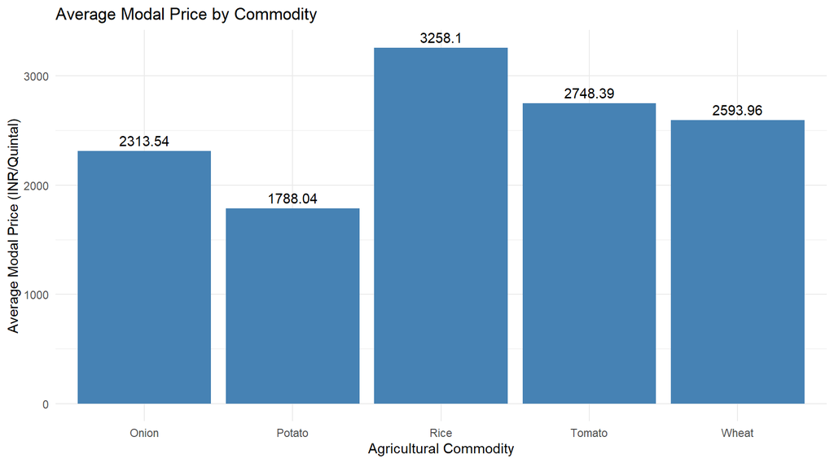

```r
# Create bar chart
ggplot(commodity_price,
       aes(x = commodity, y = average_price)) +
  geom_col(fill = "steelblue") +
  geom_text(
    aes(label = round(average_price, 2)),
    vjust = -0.5
  ) +
  labs(
    title = "Average Modal Price by Commodity",
    x = "Agricultural Commodity",
    y = "Average Modal Price (INR/Quintal)"
  ) +
  theme_minimal()
```

## 8.1 Interpretation of Commodity-wise Price Analysis

The commodity-wise analysis shows that Rice has the highest average modal price at ₹3,258.10 per quintal, followed by Tomato at ₹2,748.39 and Wheat at ₹2,593.96. Onion has an average modal price of ₹2,313.54, while Potato has the lowest average at ₹1,788.04 per quintal.

These differences indicate that agricultural commodities have different market price levels. Rice and Tomato show relatively higher average prices, whereas Potato has a comparatively lower average price.

This analysis provides a useful baseline for understanding price differences among commodities. However, average prices alone do not explain seasonal fluctuations or future price movements.

# 9 Monthly Price Trend Analysis

```r
# Calculate monthly average price
monthly_price <- agri_data %>%
  mutate(
    month_date = floor_date(arrival_date, unit = "month")
  ) %>%
  group_by(commodity, month_date) %>%
  summarise(
    average_price = mean(modal_price, na.rm = TRUE),
    .groups = "drop"
  )

# Display monthly results
print(monthly_price, n = 20)
```

```
## # A tibble: 180 × 3
##    commodity month_date average_price
##    <fct>     <date>             <dbl>
##  1 Onion     2023-01-01         2129.
##  2 Onion     2023-02-01         2331.
##  3 Onion     2023-03-01         2455.
##  4 Onion     2023-04-01         2507
##  5 Onion     2023-05-01         2439.
##  6 Onion     2023-06-01         2336.
##  7 Onion     2023-07-01         2214.
##  8 Onion     2023-08-01         2112.
##  9 Onion     2023-09-01         2079
## 10 Onion     2023-10-01         1936
## 11 Onion     2023-11-01         1992.
## 12 Onion     2023-12-01         2053.
## 13 Onion     2024-01-01         2297
## 14 Onion     2024-02-01         2391.
## 15 Onion     2024-03-01         2622.
## 16 Onion     2024-04-01         2683
## 17 Onion     2024-05-01         2492.
## 18 Onion     2024-06-01         2443.
## 19 Onion     2024-07-01         2327.
## 20 Onion     2024-08-01         2210.
## # ℹ 160 more rows
```

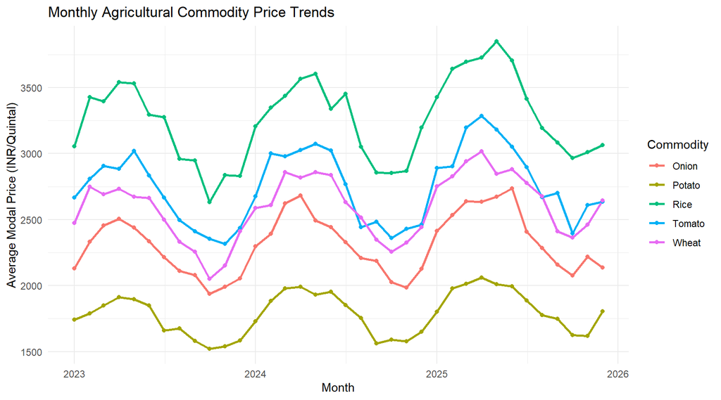

```r
# Plot monthly price trends
ggplot(monthly_price,
       aes(x = month_date,
           y = average_price,
           color = commodity)) +
  geom_line(linewidth = 0.9) +
  geom_point(size = 1.5) +
  labs(
    title = "Monthly Agricultural Commodity Price Trends",
    x = "Month",
    y = "Average Modal Price (INR/Quintal)",
    color = "Commodity"
  ) +
  theme_minimal()
```

# 10 Seasonal Price Analysis

```r
# Calculate average price by commodity and season
seasonal_price <- agri_data %>%
  group_by(commodity, season) %>%
  summarise(
    average_price = mean(modal_price, na.rm = TRUE),
    .groups = "drop"
  )

# Display seasonal price table
print(seasonal_price, n = Inf)
```

```
## # A tibble: 20 × 3
##    commodity season       average_price
##    <fct>     <fct>                <dbl>
##  1 Onion     Monsoon              2292.
##  2 Onion     Post-monsoon         2039.
##  3 Onion     Summer               2571.
##  4 Onion     Winter               2268.
##  5 Potato    Monsoon              1775.
##  6 Potato    Post-monsoon         1579.
##  7 Potato    Summer               1960.
##  8 Potato    Winter               1773.
##  9 Rice      Monsoon              3214.
## 10 Rice      Post-monsoon         2861.
## 11 Rice      Summer               3595.
## 12 Rice      Winter               3244.
## 13 Tomato    Monsoon              2704.
## 14 Tomato    Post-monsoon         2411.
## 15 Tomato    Summer               3062.
## 16 Tomato    Winter               2720.
## 17 Wheat     Monsoon              2569.
## 18 Wheat     Post-monsoon         2268.
## 19 Wheat     Summer               2827.
## 20 Wheat     Winter               2611.
```

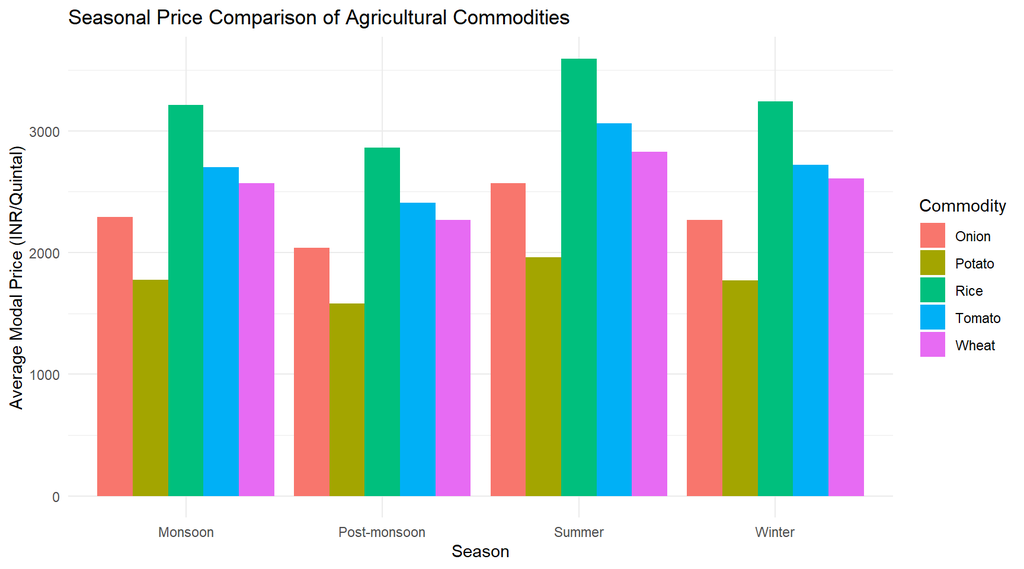

```r
# Create seasonal comparison chart
ggplot(seasonal_price,
       aes(x = season,
           y = average_price,
           fill = commodity)) +
  geom_col(position = "dodge") +
  labs(
    title = "Seasonal Price Comparison of Agricultural Commodities",
    x = "Season",
    y = "Average Modal Price (INR/Quintal)",
    fill = "Commodity"
  ) +
  theme_minimal()
```

# 11 State-wise Price Analysis

```r
state_price <- agri_data %>%
  group_by(commodity, state) %>%
  summarise(
    average_price = mean(modal_price, na.rm = TRUE),
    .groups = "drop"
  )

print(state_price, n = Inf)
```

```
## # A tibble: 30 × 3
##    commodity state          average_price
##    <fct>     <fct>                  <dbl>
##  1 Onion     Karnataka              2116.
##  2 Onion     Madhya Pradesh         2488.
##  3 Onion     Maharashtra            2192.
##  4 Onion     Rajasthan              2531.
##  5 Onion     Uttar Pradesh          2428.
##  6 Onion     West Bengal            2322.
##  7 Potato    Karnataka              1598.
##  8 Potato    Madhya Pradesh         1946.
##  9 Potato    Maharashtra            1719.
## 10 Potato    Rajasthan              1991.
## 11 Potato    Uttar Pradesh          1873.
## 12 Potato    West Bengal            1782.
```

[output cut: 18 more lines]

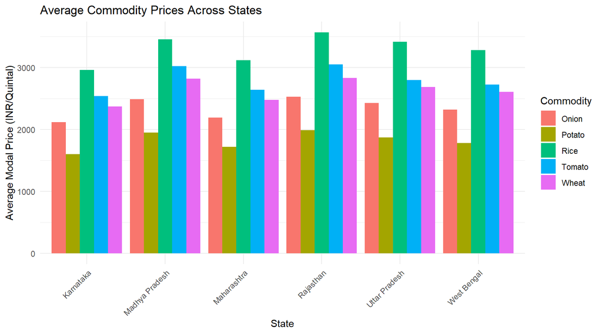

```r
# State-wise price visualization
ggplot(state_price,
       aes(x = state,
           y = average_price,
           fill = commodity)) +
  geom_col(position = "dodge") +
  labs(
    title = "Average Commodity Prices Across States",
    x = "State",
    y = "Average Modal Price (INR/Quintal)",
    fill = "Commodity"
  ) +
  theme_minimal() +
  theme(
    axis.text.x = element_text(angle = 45, hjust = 1)
  )
```

## 11.1 Interpretation of Seasonal and State-wise Price Analysis

The seasonal analysis indicates that summer has the highest average modal prices for all five agricultural commodities: Onion, Potato, Rice, Tomato and Wheat. Post-monsoon has the lowest average prices across the same commodities.

The state-wise analysis shows geographical variation in commodity prices. Rajasthan records the highest average prices for all five commodities, whereas Karnataka records the lowest average prices in this dataset.

These variations may be associated with differences in supply, demand, production, transportation and seasonal conditions. Further analysis is required to determine the relationships between these factors and commodity prices.

The results highlight the importance of considering seasonal and geographical factors when developing agricultural commodity price forecasting models.

# 12 Correlation Analysis

```r
# Select numerical variables
correlation_data <- agri_data %>%
  select(
    modal_price,
    retail_price,
    production,
    arrivals,
    temperature,
    rainfall,
    imports,
    exports
  )

# Calculate correlation matrix
cor_matrix <- cor(
  correlation_data,
  use = "complete.obs",
  method = "pearson"
)

# Display correlation matrix
round(cor_matrix, 2)
```

```
##              modal_price retail_price production arrivals temperature rainfall
## modal_price         1.00         0.96       0.15     0.05        0.10    -0.08
## retail_price        0.96         1.00      -0.02    -0.07        0.10    -0.08
## production          0.15        -0.02       1.00     0.29        0.01     0.00
## arrivals            0.05        -0.07       0.29     1.00        0.15    -0.17
## temperature         0.10         0.10       0.01     0.15        1.00     0.15
## rainfall           -0.08        -0.08       0.00    -0.17        0.15     1.00
## imports             0.24         0.22       0.14     0.03        0.01     0.00
## exports             0.46         0.26       0.51     0.36        0.00    -0.01
##              imports exports
## modal_price     0.24    0.46
## retail_price    0.22    0.26
## production      0.14    0.51
## arrivals        0.03    0.36
## temperature     0.01    0.00
## rainfall        0.00   -0.01
## imports         1.00    0.09
## exports         0.09    1.00
```

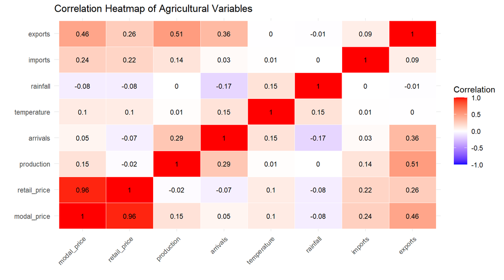

```r
# Convert correlation matrix into a data frame
library(reshape2)

cor_long <- melt(cor_matrix)

# Create correlation heatmap
ggplot(cor_long,
       aes(x = Var1, y = Var2, fill = value)) +
  geom_tile(color = "white") +
  geom_text(aes(label = round(value, 2)), size = 3) +
  scale_fill_gradient2(
    low = "blue",
    mid = "white",
    high = "red",
    midpoint = 0,
    limits = c(-1, 1)
  ) +
  labs(
    title = "Correlation Heatmap of Agricultural Variables",
    x = "",
    y = "",
    fill = "Correlation"
  ) +
  theme_minimal() +
  theme(
    axis.text.x = element_text(angle = 45, hjust = 1)
  )
```

## 12.1 Interpretation of Correlation Analysis

The correlation analysis examines the linear relationships between agricultural commodity prices and selected influencing variables.

The strongest positive correlation is observed between modal price and retail price, with a coefficient of 0.96. Exports have a moderate positive correlation with modal price (0.46), while imports show a weak positive correlation (0.24).

Production (0.15) and temperature (0.10) have weak positive relationships with modal price. Arrivals (0.05) show almost no overall linear relationship, whereas rainfall (-0.08) has a very weak negative relationship.

These findings provide an initial understanding of the relationships between market prices and agricultural factors. However, correlation does not establish causation. Commodity-specific and time-series analysis is required before selecting variables for the forecasting model.

# 13 Commodity-wise Correlation Analysis

```r
commodity_correlation <- agri_data %>%
  group_by(commodity) %>%
  summarise(
    Price_Retail = cor(modal_price, retail_price,
                       use = "complete.obs"),
    Price_Production = cor(modal_price, production,
                           use = "complete.obs"),
    Price_Arrivals = cor(modal_price, arrivals,
                         use = "complete.obs"),
    Price_Temperature = cor(modal_price, temperature,
                            use = "complete.obs"),
    Price_Rainfall = cor(modal_price, rainfall,
                         use = "complete.obs"),
    Price_Imports = cor(modal_price, imports,
                        use = "complete.obs"),
    Price_Exports = cor(modal_price, exports,
                        use = "complete.obs"),
    .groups = "drop"
  )

print(commodity_correlation, n = Inf)
```

```
## # A tibble: 5 × 8
##   commodity Price_Retail Price_Production Price_Arrivals Price_Temperature
##   <fct>            <dbl>            <dbl>          <dbl>             <dbl>
## 1 Onion            0.977           0.0126         0.0216             0.248
## 2 Potato           0.978          -0.0138        -0.0106             0.177
## 3 Rice             0.979          -0.0129        -0.0162             0.185
## 4 Tomato           0.979           0.0159         0.0175             0.189
## 5 Wheat            0.977          -0.0203         0.0594             0.170
## # ℹ 3 more variables: Price_Rainfall <dbl>, Price_Imports <dbl>,
## #   Price_Exports <dbl>
```

```r
print(commodity_correlation, width = Inf)
```

```
## # A tibble: 5 × 8
##   commodity Price_Retail Price_Production Price_Arrivals Price_Temperature
##   <fct>            <dbl>            <dbl>          <dbl>             <dbl>
## 1 Onion            0.977           0.0126         0.0216             0.248
## 2 Potato           0.978          -0.0138        -0.0106             0.177
## 3 Rice             0.979          -0.0129        -0.0162             0.185
## 4 Tomato           0.979           0.0159         0.0175             0.189
## 5 Wheat            0.977          -0.0203         0.0594             0.170
##   Price_Rainfall Price_Imports Price_Exports
##            <dbl>         <dbl>         <dbl>
## 1         -0.150       0.0106        -0.0134
## 2         -0.112      -0.0991        -0.0178
## 3         -0.131      -0.0624        -0.0286
## 4         -0.136      -0.00649       -0.0204
## 5         -0.139       0.0250        -0.0224
```

# 14 Check Monthly Data Availability

```r
monthly_data_check <- agri_data %>%
  mutate(month_date = lubridate::floor_date(arrival_date, "month")) %>%
  group_by(commodity) %>%
  summarise(
    Total_Records = n(),
    First_Date = min(arrival_date, na.rm = TRUE),
    Last_Date = max(arrival_date, na.rm = TRUE),
    Distinct_Months = n_distinct(month_date),
    .groups = "drop"
  )

print(monthly_data_check)
```

```
## # A tibble: 5 × 5
##   commodity Total_Records First_Date Last_Date  Distinct_Months
##   <fct>             <int> <date>     <date>               <int>
## 1 Onion               360 2023-01-01 2025-12-01              36
## 2 Potato              360 2023-01-01 2025-12-01              36
## 3 Rice                360 2023-01-01 2025-12-01              36
## 4 Tomato              360 2023-01-01 2025-12-01              36
## 5 Wheat               360 2023-01-01 2025-12-01              36
```

# 15 Check Market-Level Observations

```r
market_check <- agri_data %>%
  mutate(month_date = lubridate::floor_date(arrival_date, "month")) %>%
  group_by(commodity, month_date) %>%
  summarise(
    Records = n(),
    Unique_Markets = n_distinct(market),
    Unique_States = n_distinct(state),
    .groups = "drop"
  )

print(market_check, n = 20)
```

```
## # A tibble: 180 × 5
##    commodity month_date Records Unique_Markets Unique_States
##    <fct>     <date>       <int>          <int>         <int>
##  1 Onion     2023-01-01      10             10             6
##  2 Onion     2023-02-01      10             10             6
##  3 Onion     2023-03-01      10             10             6
##  4 Onion     2023-04-01      10             10             6
##  5 Onion     2023-05-01      10             10             6
##  6 Onion     2023-06-01      10             10             6
##  7 Onion     2023-07-01      10             10             6
##  8 Onion     2023-08-01      10             10             6
##  9 Onion     2023-09-01      10             10             6
## 10 Onion     2023-10-01      10             10             6
## 11 Onion     2023-11-01      10             10             6
## 12 Onion     2023-12-01      10             10             6
## 13 Onion     2024-01-01      10             10             6
## 14 Onion     2024-02-01      10             10             6
## 15 Onion     2024-03-01      10             10             6
## 16 Onion     2024-04-01      10             10             6
## 17 Onion     2024-05-01      10             10             6
## 18 Onion     2024-06-01      10             10             6
## 19 Onion     2024-07-01      10             10             6
## 20 Onion     2024-08-01      10             10             6
## # ℹ 160 more rows
```

# 16 National Monthly Price Aggregation

```r
weighted_avg <- function(price, arrivals) {
  valid <- !is.na(price) & !is.na(arrivals) &
           is.finite(price) & is.finite(arrivals) &
           arrivals > 0

  if (!any(valid)) {
    return(NA_real_)
  }

  weighted.mean(price[valid], arrivals[valid])
}

national_monthly <- agri_data %>%
  mutate(
    month_date = lubridate::floor_date(arrival_date, "month")
  ) %>%
  group_by(commodity, month_date) %>%
  summarise(
    national_modal_price = weighted_avg(modal_price, arrivals),

    national_retail_price = weighted_avg(retail_price, arrivals),

    total_arrivals = sum(arrivals, na.rm = TRUE),

    avg_production = mean(production, na.rm = TRUE),

    avg_temperature = mean(temperature, na.rm = TRUE),

    avg_rainfall = mean(rainfall, na.rm = TRUE),

    avg_imports = mean(imports, na.rm = TRUE),

    avg_exports = mean(exports, na.rm = TRUE),

    .groups = "drop"
  )

print(national_monthly, n = 20)
```

```
## # A tibble: 180 × 10
##    commodity month_date national_modal_price national_retail_price
##    <fct>     <date>                    <dbl>                 <dbl>
##  1 Onion     2023-01-01                2115.                  28.5
##  2 Onion     2023-02-01                2313.                  30.4
##  3 Onion     2023-03-01                2447.                  32.5
##  4 Onion     2023-04-01                2475.                  32.9
##  5 Onion     2023-05-01                2401.                  31.5
##  6 Onion     2023-06-01                2326.                  31.5
##  7 Onion     2023-07-01                2205.                  29.5
##  8 Onion     2023-08-01                2091.                  27.8
##  9 Onion     2023-09-01                2046.                  27.7
## 10 Onion     2023-10-01                1921.                  25.5
## 11 Onion     2023-11-01                1972.                  26.4
## 12 Onion     2023-12-01                2031.                  27.1
## 13 Onion     2024-01-01                2297.                  30.4
## 14 Onion     2024-02-01                2371.                  31.3
## 15 Onion     2024-03-01                2556.                  33.9
## 16 Onion     2024-04-01                2660.                  35.0
## 17 Onion     2024-05-01                2461.                  33.0
## 18 Onion     2024-06-01                2428.                  32.2
## 19 Onion     2024-07-01                2320.                  30.7
## 20 Onion     2024-08-01                2194.                  29.3
## # ℹ 160 more rows
## # ℹ 6 more variables: total_arrivals <dbl>, avg_production <dbl>,
## #   avg_temperature <dbl>, avg_rainfall <dbl>, avg_imports <dbl>,
## #   avg_exports <dbl>
```

# 17 National Monthly Price Trends

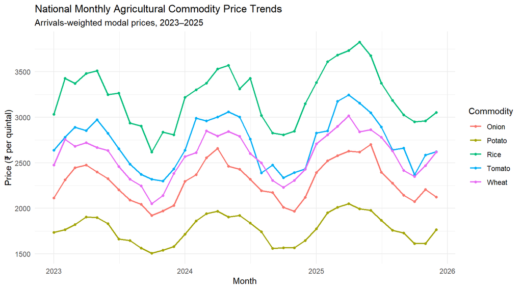

```r
ggplot(national_monthly,
       aes(x = month_date,
           y = national_modal_price,
           color = commodity)) +

  geom_line(linewidth = 0.8) +

  geom_point(size = 1.2) +

  labs(
    title = "National Monthly Agricultural Commodity Price Trends",
    subtitle = "Arrivals-weighted modal prices, 2023–2025",
    x = "Month",
    y = "Price (₹ per quintal)",
    color = "Commodity"
  ) +

  theme_minimal()
```

# 18 Install and Load Forecasting Packages

```r
if (!requireNamespace("forecast", quietly = TRUE)) {
  install.packages("forecast")
}

library(forecast)
library(dplyr)
library(ggplot2)
```

# 19 Split Data into Training and Testing

```r
train_data <- national_monthly %>%
  filter(month_date <= as.Date("2025-06-01"))

test_data <- national_monthly %>%
  filter(month_date >= as.Date("2025-07-01"))

# Check observations
train_data %>%
  count(commodity)
```

```
## # A tibble: 5 × 2
##   commodity     n
##   <fct>     <int>
## 1 Onion        30
## 2 Potato       30
## 3 Rice         30
## 4 Tomato       30
## 5 Wheat        30
```

```r
test_data %>%
  count(commodity)
```

```
## # A tibble: 5 × 2
##   commodity     n
##   <fct>     <int>
## 1 Onion         6
## 2 Potato        6
## 3 Rice          6
## 4 Tomato        6
## 5 Wheat         6
```